# Question

Camila está diseñando un recipiente cilíndrico para un proyecto escolar. El recipiente tiene una base circular de radio 23 cm y una altura de 60 cm, como se muestra en la figura.

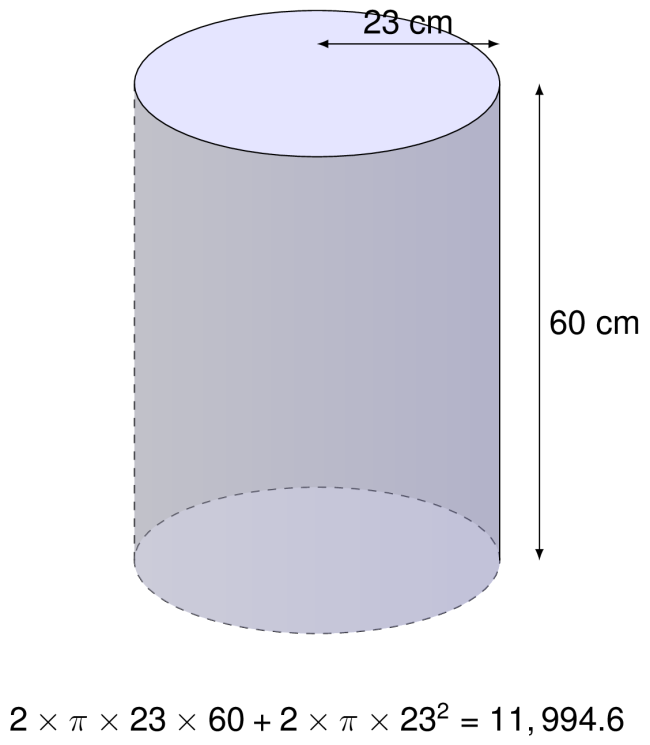

Para calcular la cantidad de material necesario para construir el recipiente, Camila plantea la siguiente operación:

$$2 \times \pi \times 23 \times 60 + 2
\times \pi \times 23^2 = 11,994.6$$

¿A qué corresponde el resultado de la anterior operación?

## Answerlist

- Al perímetro de la tapa del vaso
- Al volumen del vaso
- Al área total del vaso (incluyendo todas sus caras)
- Al área de la tapa del vaso

# Solution

Para resolver este problema, debemos identificar qué cálculo se está realizando con la fórmula $2 \times \pi \times 23 \times 60 + 2 \times \pi \times 23^2 = 11,994.6$.

Analizando la fórmula por partes:

1. $2 \times \pi \times r \times h$ corresponde al área lateral del cilindro
   - El perímetro de la base es $2 \times \pi \times r$
   - Al multiplicar por la altura $h$, obtenemos el área lateral
2. $2 \times \pi \times r^2$ corresponde al área de las dos bases circulares
   - El área de un círculo es $\pi \times r^2$
   - Al multiplicar por 2, obtenemos el área de ambas bases (superior e inferior)
3. La suma de ambas expresiones nos da el área total del cilindro (todas sus caras)

Por lo tanto, la fórmula $A_T = 2 \times \pi \times r \times h + 2 \times \pi \times r^2$ es la fórmula del área total de un cilindro.

Sustituyendo los valores: - Radio de la base: $r = 23 \text{ cm}$ - Altura: $h = 60 \text{ cm}$

Calculamos: - Área lateral: $A_L = 2 \times \pi \times 23 \times 60 = 8,670.8 \text{ cm}^2$ - Área de las dos bases: $A_B = 2 \times \pi \times 23^2 = 2 \times 1,661.9 = 3,323.81 \text{ cm}^2$ - Área total: $A_T = A_L + A_B = 8,670.8 + 3,323.81 = 11,994.6 \text{ cm}^2$

El resultado corresponde al área total del vaso cilíndrico, que representa la cantidad total de material necesario para construirlo, incluyendo la superficie lateral y las dos bases circulares.

## Answerlist

- Falso
- Falso
- Verdadero
- Falso

# Meta-information

exname: Area_Total_Cilindro extype: schoice exsolution: 0010 exshuffle: TRUE